# God in Philosophy

# 1. Introduction

In the beginning of *History of Western Philosophy*, Russell gives a beautiful introduction to the subject Philosophy by defining it as a middle ground between Science and Theology:

> “Philosophy, as I shall understand the word, is something intermediate between theology and science. Like theology, it consists of speculations on matters as to which deﬁnite knowledge has, so far, been unascertainable; but like science, it appeals to human reason rather than to authority, whether that of tradition or that of revelation. All deﬁnite knowledge—so I should contend—belongs to science; all dogma as to what surpasses deﬁnite knowledge belongs to theology. But between theology and science there is a No Man’s Land, exposed to attack from both sides; this No Man’s Land is philosophy.”

The concept of God is an important topic of many philosophy articles. Philosophers have sought to justify it or to demolish it or to show that it lies outside reason’s grasp. By analyzing the history of philosophy data set, we are going to explore the sentiments of different philosophy schools towards God and the main topics when they discussed about God.

# 2. Data Processing

The History of Philosophy Dataset is available for download at https://www.kaggle.com/kouroshalizadeh/history-of-philosophy. It is a .csv file that includes 360808 observations and 11 variables. These observations are sentences taken from 59 texts and 13 different schools spanning the history of philosophy. Below shows some samples of observations and a list of all 13 schools involved.

|  | title | author | school | sentence_spacy | sentence_str | original_publication_date | corpus_edition_date | sentence_length | sentence_lowered | tokenized_txt | lemmatized_str |
| --- | --- | --- | --- | --- | --- | --- | --- | --- | --- | --- | --- |
| 1 | Plato - Complete Works | Plato | plato | What's new, Socrates, to make you leave your usual haunts in the Lyceum and spend your time here by the king archon's court? | What's new, Socrates, to make you leave your usual haunts in the Lyceum and spend your time here by the king archon's court? | -350 | 1997 | 125 | what's new, socrates, to make you leave your usual haunts in the lyceum and spend your time here by the king archon's court? | ['what', 'new', 'socrates', 'to', 'make', 'you', 'leave', 'your', 'usual', 'haunts', 'in', 'the', 'lyceum', 'and', 'spend', 'your', 'time', 'here', 'by', 'the', 'king', 'archon', 'court'] | what be new , Socrates , to make -PRON- leave -PRON- usual haunt in the Lyceum and spend -PRON- time here by the king archon 's court ? |
| 2 | Plato - Complete Works | Plato | plato | Surely you are not prosecuting anyone before the king archon as I am? | Surely you are not prosecuting anyone before the king archon as I am? | -350 | 1997 | 69 | surely you are not prosecuting anyone before the king archon as i am? | ['surely', 'you', 'are', 'not', 'prosecuting', 'anyone', 'before', 'the', 'king', 'archon', 'as', 'am'] | surely -PRON- be not prosecute anyone before the king archon as -PRON- be ? |
| 3 | Plato - Complete Works | Plato | plato | The Athenians do not call this a prosecution but an indictment, Euthyphro. | The Athenians do not call this a prosecution but an indictment, Euthyphro. | -350 | 1997 | 74 | the athenians do not call this a prosecution but an indictment, euthyphro. | ['the', 'athenians', 'do', 'not', 'call', 'this', 'prosecution', 'but', 'an', 'indictment', 'euthyphro'] | the Athenians do not call this a prosecution but an indictment , Euthyphro . |
| 4 | Plato - Complete Works | Plato | plato | What is this you say? | What is this you say? | -350 | 1997 | 21 | what is this you say? | ['what', 'is', 'this', 'you', 'say'] | what be this -PRON- say ? |
| 5 | Plato - Complete Works | Plato | plato | Someone must have indicted you, for you are not going to tell me that you have indicted someone else. | Someone must have indicted you, for you are not going to tell me that you have indicted someone else. | -350 | 1997 | 101 | someone must have indicted you, for you are not going to tell me that you have indicted someone else. | ['someone', 'must', 'have', 'indicted', 'you', 'for', 'you', 'are', 'not', 'going', 'to', 'tell', 'me', 'that', 'you', 'have', 'indicted', 'someone', 'else'] | someone must have indict -PRON- , for -PRON- be not go to tell -PRON- that -PRON- have indict someone else . |
| 6 | Plato - Complete Works | Plato | plato | But someone else has indicted you? | But someone else has indicted you? | -350 | 1997 | 34 | but someone else has indicted you? | ['but', 'someone', 'else', 'has', 'indicted', 'you'] | but someone else have indict -PRON- ? |

```
 [1] "plato"           "aristotle"       "empiricism"      "rationalism"     "analytic"
 [6] "continental"     "phenomenology"   "german_idealism" "communism"       "capitalism"
[11] "stoicism"        "nietzsche"       "feminism"
```

In this project, we mainly focus on theology topic in Philosophy. Therefore, we filter sentences containing keywords *god* or *lord* to finish following analysis. The filtered dataset contains 8183 sentences.

```
[1] 8183   11
```

# 3. Data Analysis: Sentence Distribution

In the following, I want to check how these sentences distribute over years and different schools. First two charts below show that school Rationalism spent great portion of texts discussing topics related to God, so as Stoicism, Plato and Nietzsche. In addition, in 350 B.C. and between 1650 A.C. and 1750 B.C., theology may be a popular topic.

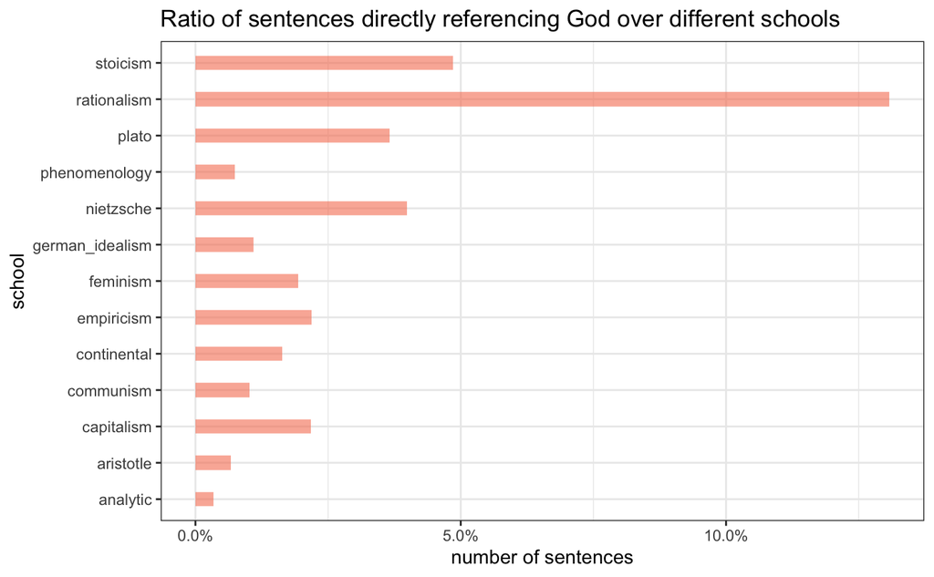

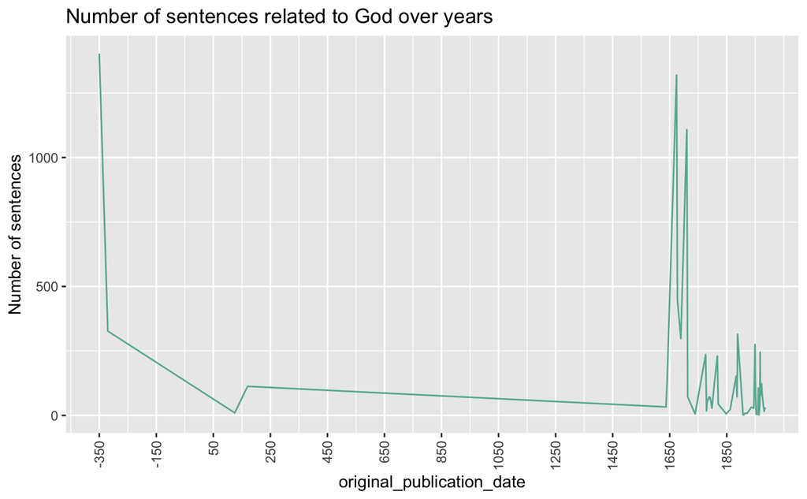

What’s more, below graph indicates different schools devote various length to the description of God. Rationalism describe this field in details, and so do Plato and Empiricism.

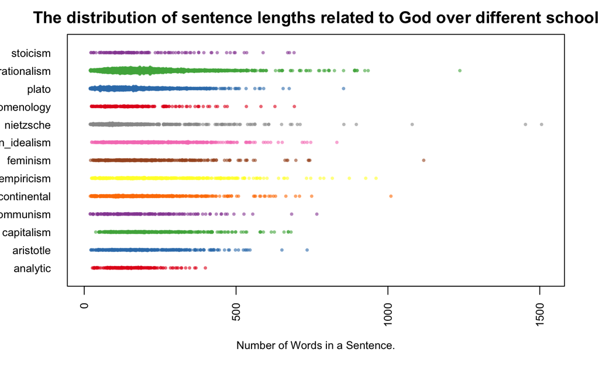

# 4. Data Analysis: Sentiment Analysis

## 4.1 Text Proprocessing

Here method Sentiment Analysis is used to show authors’ emotion behind the sentences. Below are some examples of results of sentiment analysis.

|  | title | author | school | sentence_spacy | sentence_str | original_publication_date | corpus_edition_date | sentence_length | sentence_lowered | tokenized_txt | sentences | word.count | anger | anticipation | disgust | fear | joy | sadness | surprise | trust | negative | positive | sent.id |
| --- | --- | --- | --- | --- | --- | --- | --- | --- | --- | --- | --- | --- | --- | --- | --- | --- | --- | --- | --- | --- | --- | --- | --- |
| 22 | Plato - Complete Works | Plato | plato | Strange things, to hear him tell it, for he says that I am a maker of gods, and on the ground that I create new gods while not believing in the old gods, he has indicted me for their sake, as he puts … | Strange things, to hear him tell it, for he says that I am a maker of gods, and on the ground that I create new gods while not believing in the old gods, he has indicted me for their sake, as he puts … | -350 | 1997 | 203 | strange things, to hear him tell it, for he says that i am a maker of gods, and on the ground that i create new gods while not believing in the old gods, he has indicted me for their sake, as he puts … | ['strange', 'things', 'to', 'hear', 'him', 'tell', 'it', 'for', 'he', 'says', 'that', 'am', 'maker', 'of', 'gods', 'and', 'on', 'the', 'ground', 'that', 'create', 'new', 'gods', 'while', 'not', 'belie… | strange things, to hear him tell it, for he says that i am a maker of gods, and on the ground that i create new gods while not believing in the old gods, he has indicted me for their sake, as he puts … | 44 | 0.00000000 | 0 | 0.000000 | 0.00000000 | 0.02272211 | 0.00000000 | 0.000000 | 0.04544422 | 0.00000000 | 0.04544422 | 1 |
| 60 | Plato - Complete Works | Plato | plato | It is indeed most important, my admirable Euthyphro, that I should become your pupil, and as regards this indictment, challenge Meletus about these very things and say to him: that in the past too I c… | It is indeed most important, my admirable Euthyphro, that I should become your pupil, and as regards this indictment, challenge Meletus about these very things and say to him: that in the past too I c… | -350 | 1997 | 372 | it is indeed most important, my admirable euthyphro, that i should become your pupil, and as regards this indictment, challenge meletus about these very things and say to him: that in the past too i c… | ['it', 'is', 'indeed', 'most', 'important', 'my', 'admirable', 'euthyphro', 'that', 'should', 'become', 'your', 'pupil', 'and', 'as', 'regards', 'this', 'indictment', 'challenge', 'meletus', 'about', … | it is indeed most important, my admirable euthyphro, that i should become your pupil, and as regards this indictment, challenge meletus about these very things and say to him: that in the past too i c… | 66 | 0.03029844 | 0 | 0.000000 | 0.03029844 | 0.01514922 | 0.01514922 | 0.000000 | 0.03029844 | 0.04544766 | 0.04544766 | 1 |
| 66 | Plato - Complete Works | Plato | plato | I know that other people as well as this Meletus do not even seem to notice you, whereas he sees me so sharply and clearly that he indicts me for ungodliness. | I know that other people as well as this Meletus do not even seem to notice you, whereas he sees me so sharply and clearly that he indicts me for ungodliness. | -350 | 1997 | 158 | i know that other people as well as this meletus do not even seem to notice you, whereas he sees me so sharply and clearly that he indicts me for ungodliness. | ['know', 'that', 'other', 'people', 'as', 'well', 'as', 'this', 'meletus', 'do', 'not', 'even', 'seem', 'to', 'notice', 'you', 'whereas', 'he', 'sees', 'me', 'so', 'sharply', 'and', 'clearly', 'that',… | i know that other people as well as this meletus do not even seem to notice you, whereas he sees me so sharply and clearly that he indicts me for ungodliness. | 31 | 0.00000000 | 0 | 0.000000 | 0.00000000 | 0.00000000 | 0.00000000 | 0.000000 | 0.00000000 | 0.00000000 | 0.00000000 | 1 |
| 68 | Plato - Complete Works | Plato | plato | what kind of thing do you say that godliness and ungodliness are, both as regards murder and other things; or is the pious not the same and alike in every action, and the impious the opposite of all t… | what kind of thing do you say that godliness and ungodliness are, both as regards murder and other things; or is the pious not the same and alike in every action, and the impious the opposite of all t… | -350 | 1997 | 258 | what kind of thing do you say that godliness and ungodliness are, both as regards murder and other things; or is the pious not the same and alike in every action, and the impious the opposite of all t… | ['what', 'kind', 'of', 'thing', 'do', 'you', 'say', 'that', 'godliness', 'and', 'ungodliness', 'are', 'both', 'as', 'regards', 'murder', 'and', 'other', 'things', 'or', 'is', 'the', 'pious', 'not', 't… | what kind of thing do you say that godliness and ungodliness are, both as regards murder and other things; or is the pious not the same and alike in every action, and the impious the opposite of all t… | 50 | 0.01999600 | 0 | 0.039992 | 0.01999600 | 0.01999600 | 0.03999200 | 0.019996 | 0.03999200 | 0.01999600 | 0.05998800 | 1 |
| 73 | Plato - Complete Works | Plato | plato | I have already said to others that such actions are right, not to favor the ungodly, whoever they are. | I have already said to others that such actions are right, not to favor the ungodly, whoever they are. | -350 | 1997 | 102 | i have already said to others that such actions are right, not to favor the ungodly, whoever they are. | ['have', 'already', 'said', 'to', 'others', 'that', 'such', 'actions', 'are', 'right', 'not', 'to', 'favor', 'the', 'ungodly', 'whoever', 'they', 'are'] | i have already said to others that such actions are right, not to favor the ungodly, whoever they are. | 19 | 0.00000000 | 0 | 0.000000 | 0.00000000 | 0.00000000 | 0.05260389 | 0.000000 | 0.00000000 | 0.05260389 | 0.00000000 | 1 |
| 74 | Plato - Complete Works | Plato | plato | These people themselves believe that Zeus is the best and most just of the gods, yet they agree that he bound his father because he unjustly swallowed his sons, and that he in turn castrated his fathe… | These people themselves believe that Zeus is the best and most just of the gods, yet they agree that he bound his father because he unjustly swallowed his sons, and that he in turn castrated his fathe… | -350 | 1997 | 222 | these people themselves believe that zeus is the best and most just of the gods, yet they agree that he bound his father because he unjustly swallowed his sons, and that he in turn castrated his fathe… | ['these', 'people', 'themselves', 'believe', 'that', 'zeus', 'is', 'the', 'best', 'and', 'most', 'just', 'of', 'the', 'gods', 'yet', 'they', 'agree', 'that', 'he', 'bound', 'his', 'father', 'because',… | these people themselves believe that zeus is the best and most just of the gods, yet they agree that he bound his father because he unjustly swallowed his sons, and that he in turn castrated his fathe… | 40 | 0.00000000 | 0 | 0.000000 | 0.00000000 | 0.00000000 | 0.00000000 | 0.000000 | 0.02499375 | 0.02499375 | 0.02499375 | 1 |

Below are some emotionally charged sentences of several representative schools, Rationalism, Plato and Nietzsche. It is kind of obvious that the represented sentences of schools Rationalism and Plato is pretty positive towards the concept of God. Especially Rationalism related God with many virtues like knowledge, truth and perfection, which suggesting rationality and religion are not completely antagonistic. In fact, Rationalism has a branch called theistic rationalism, which believes natural religion, Christianity, and rationalism typically coexist compatibly. On the contrary, represented sentences of school Nietzsche and Feminism is relatively negative, which is also proved in the table below.

```
[1] "Rationalism"
[1] "therefore neither can the traitor judas complain of god's foreknowledge."
[2] "thought is an attribute of god .)"
[3] "thus saith the lord:"
[4] "no one can hate god."
[5] "good is the knowledge of god."
[6] "therefore neither can the traitor judas complain of god's foreknowledge."
[7] ", the nature of god rejoices in infinite perfection; and such rejoicing is."
[8] "therefore, truth is god."
[1] "Plato"
[1] "well now, how can one argue for the existence of gods without getting angry?"
[2] "good god, yes, hippias."
[3] "lord, yes, i do, socrates."
[4] "ares is the god of war."
[5] "good god, yes, hippias."
```

[output cut: 21 more lines]

| school | negative |
| --- | --- |
| nietzsche | 0.04930713 |
| communism | 0.04609053 |
| feminism | 0.03959411 |
| continental | 0.03420381 |
| capitalism | 0.03093685 |
| phenomenology | 0.02940636 |
| analytic | 0.02737431 |
| stoicism | 0.02573403 |
| empiricism | 0.02568611 |
| plato | 0.02514014 |

[output cut: 3 more lines]

## 4.2 Clustering of emotions

The result of heat map is consistent with common sense that sentiments of same type would have stronger connection with each other. The heat map and bar chart of Sentiment Distribution below also indicate that four protrude sentiments towards God: trust, anticipation, joy and fear; mostly positive.

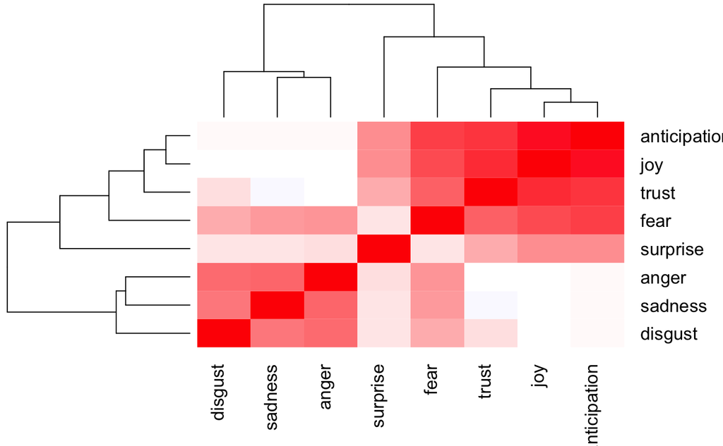

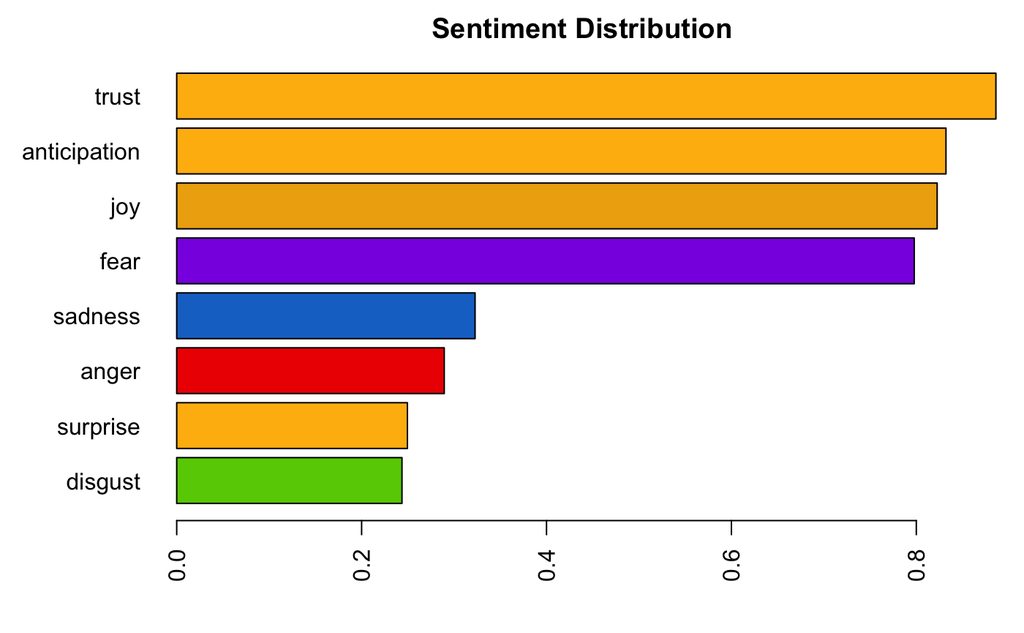

## 4.3 KMeans Clustering: grouping authors emotions

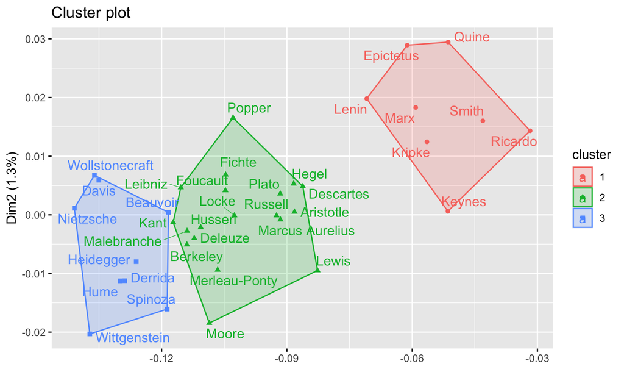

From above clustering chart, we apply K-Means on sentiment analysis result to split authors into 3 different groups. Table below shows that not all authors from same school will fall into the same group, suggesting that philosophers from same school may have different attitude towards theology topic.

```
* value -> value...1
* value -> value...2
```

| cluster | author | school |
| --- | --- | --- |
| 1 | Kripke | analytic |
| 1 | Quine | analytic |
| 1 | Keynes | capitalism |
| 1 | Ricardo | capitalism |
| 1 | Smith | capitalism |
| 1 | Lenin | communism |
| 1 | Marx | communism |
| 1 | Epictetus | stoicism |
| 2 | Lewis | analytic |
| 2 | Moore | analytic |

[output cut: 26 more lines]

# 5. Data Analysis - Topic Modeling

## 5.1 Topic Modeling

Topic modeling is a type of statistical modeling for discovering the abstract “topics” that occur in a collection of documents. Here I am going to apply LDA to the dataset and split these sentences into topics.

```
      [,1]         [,2]          [,3]           [,4]            [,5]         [,6]
 [1,] "create"     "creature"    "therein"      "looks"         "inclines"   "admits"
 [2,] "attributes" "whereof"     "modes"        "def"           "coroll"     "plans"
 [3,] "evident"    "negative"    "nations"      "moses"         "carries"    "splendid"
 [4,] "pure"       "practical"   "morality"     "determination" "drawn"      "ontological"
 [5,] "woman"      "son"         "mother"       "ancient"       "authority"  "direct"
 [6,] "sensations" "fashion"     "representing" "applying"      "obviously"  "stir"
 [7,] "shall"      "better"      "thee"         "thy"           "prince"     "thyself"
 [8,] "rent"       "landlords"   "value"        "tax"           "fall"       "price"
 [9,] "loved"      "sacrifices"  "fire"         "pray"          "temples"    "homer"
[10,] "must"       "proved"      "animal"       "godel"         "discovered" "task"
[11,] "volitions"  "efficacious" "admirable"    "occasional"    "impact"     "lordly"
[12,] "behind"     "nearly"      "rights"       "beneath"       "nowadays"   "depth"
[13,] "ever"       "day"         "cases"        "event"         "complex"    "alternative"
[14,] "love"       "toward"      "happy"        "jesus"         "salvation"  "impression"
```

[output cut: 17 more lines]

Based on the most popular terms and the most salient terms for each topic, I manually assign a hashtag to each topic: “creator”, “ruler”, “history”, “practice”, “human”, “sense”, “appellation”, “capital”, “sacrifice”, “prove”, “impact”, “location”, “time”, “salvation”, “language”. This assignment process is not objective and does not guarantee accuracy.

|  | title | author | school | original_publication_date | sentence_length | sentence_lowered | creator | ruler | history | practice | human | sense | appellation | capital | sacrifice | prove | impact | location | time | salvation | language |
| --- | --- | --- | --- | --- | --- | --- | --- | --- | --- | --- | --- | --- | --- | --- | --- | --- | --- | --- | --- | --- | --- |
| 22 | Plato - Complete Works | Plato | plato | -350 | 203 | strange things, to hear him tell it, for he says that i am a maker of gods, and on the ground that i create new gods while not believing in the old gods, he has indicted me for their sake, as he puts … | 0.07960199 | 0.04975124 | 0.04975124 | 0.06467662 | 0.09452736 | 0.04975124 | 0.06467662 | 0.07960199 | 0.12437811 | 0.04975124 | 0.04975124 | 0.04975124 | 0.07960199 | 0.06467662 | 0.04975124 |
| 60 | Plato - Complete Works | Plato | plato | -350 | 372 | it is indeed most important, my admirable euthyphro, that i should become your pupil, and as regards this indictment, challenge meletus about these very things and say to him: that in the past too i c… | 0.05777778 | 0.08444444 | 0.05777778 | 0.04444444 | 0.05777778 | 0.04444444 | 0.08444444 | 0.04444444 | 0.12444444 | 0.07111111 | 0.07111111 | 0.08444444 | 0.05777778 | 0.05777778 | 0.05777778 |
| 66 | Plato - Complete Works | Plato | plato | -350 | 158 | i know that other people as well as this meletus do not even seem to notice you, whereas he sees me so sharply and clearly that he indicts me for ungodliness. | 0.05291005 | 0.06878307 | 0.06878307 | 0.05291005 | 0.06878307 | 0.10052910 | 0.05291005 | 0.05291005 | 0.06878307 | 0.06878307 | 0.06878307 | 0.08465608 | 0.08465608 | 0.05291005 | 0.05291005 |
| 68 | Plato - Complete Works | Plato | plato | -350 | 258 | what kind of thing do you say that godliness and ungodliness are, both as regards murder and other things; or is the pious not the same and alike in every action, and the impious the opposite of all t… | 0.04975124 | 0.10945274 | 0.06467662 | 0.06467662 | 0.06467662 | 0.04975124 | 0.07960199 | 0.04975124 | 0.09452736 | 0.06467662 | 0.06467662 | 0.04975124 | 0.07960199 | 0.04975124 | 0.06467662 |
| 73 | Plato - Complete Works | Plato | plato | -350 | 102 | i have already said to others that such actions are right, not to favor the ungodly, whoever they are. | 0.07471264 | 0.05747126 | 0.07471264 | 0.05747126 | 0.07471264 | 0.05747126 | 0.05747126 | 0.05747126 | 0.10919540 | 0.05747126 | 0.05747126 | 0.05747126 | 0.07471264 | 0.05747126 | 0.07471264 |
| 74 | Plato - Complete Works | Plato | plato | -350 | 222 | these people themselves believe that zeus is the best and most just of the gods, yet they agree that he bound his father because he unjustly swallowed his sons, and that he in turn castrated his fathe… | 0.10784314 | 0.06372549 | 0.04901961 | 0.06372549 | 0.12254902 | 0.04901961 | 0.04901961 | 0.04901961 | 0.09313725 | 0.04901961 | 0.04901961 | 0.09313725 | 0.04901961 | 0.04901961 | 0.06372549 |

## 5.2 Clustering of topics

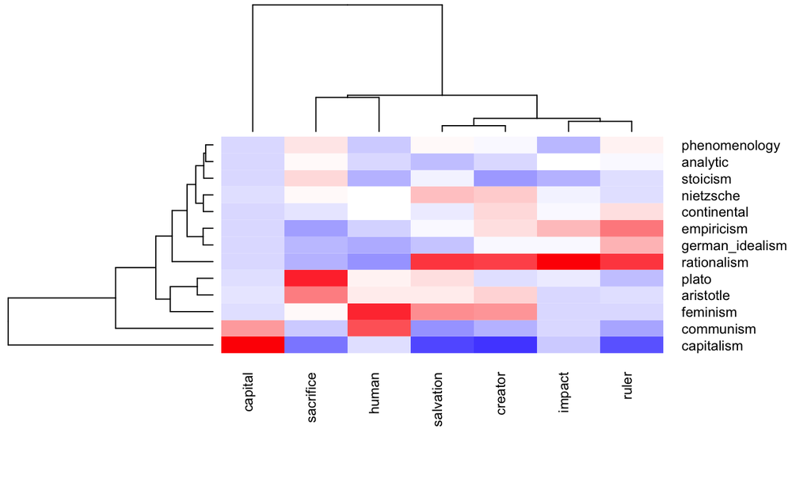

Above heatmap shows that Rationalism has positive correlation with identity attribute of God such as creator, ruler and savior. On the contrary, School Feminism and Communism more concentrate on the human topic instead of the attribute of God.